# Data Analyst Job Postings — Salary & Experience Report

Data Report

May 24, 2026

## Introduction

This report summarizes a **small convenience sample** (402 job postings) of data analyst roles, focusing on estimated median salary, stated minimum experience, and whether postings mention **R** and/or **Python** among required programming languages. Salaries and experience requirements come from posting text and automated extraction, so values may be incomplete or noisy.

Because the sample is modest and not randomly drawn, results describe **patterns in this dataset only** — not the full labor market. Treat findings as exploratory.

## Experience vs. median salary

More experience is often associated with higher pay, but the relationship is rarely perfect in job-ad data (location, industry, and seniority titles all matter). The scatter plot below uses postings with **numeric** minimum experience and a recorded median salary estimate (309 of 402 rows).

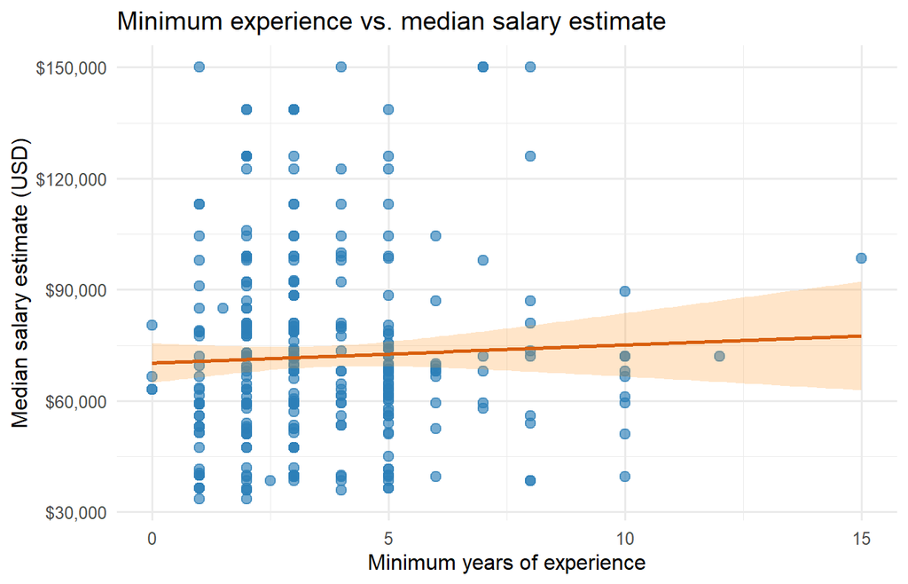

**Interpretation:** If points slope upward, higher stated experience tends to coincide with higher salary estimates in this sample. A wide cloud or flat trend suggests weak association — common when salaries vary by region and role level while experience fields are inconsistently reported. The fitted line is illustrative only; with 309 observations, a few high- or low-salary outliers can shift the slope noticeably. Roughly 93 postings lack usable experience values and are omitted here.

## Salary by data language category

Postings were classified from the **Programming Lanuguage** field into **R**, **Python**, **Both**, or **Neither** (mentions of R and/or Python in the text; other tools such as SQL-only map to Neither). The box plot compares median salary estimates across these groups (400 postings with salary).

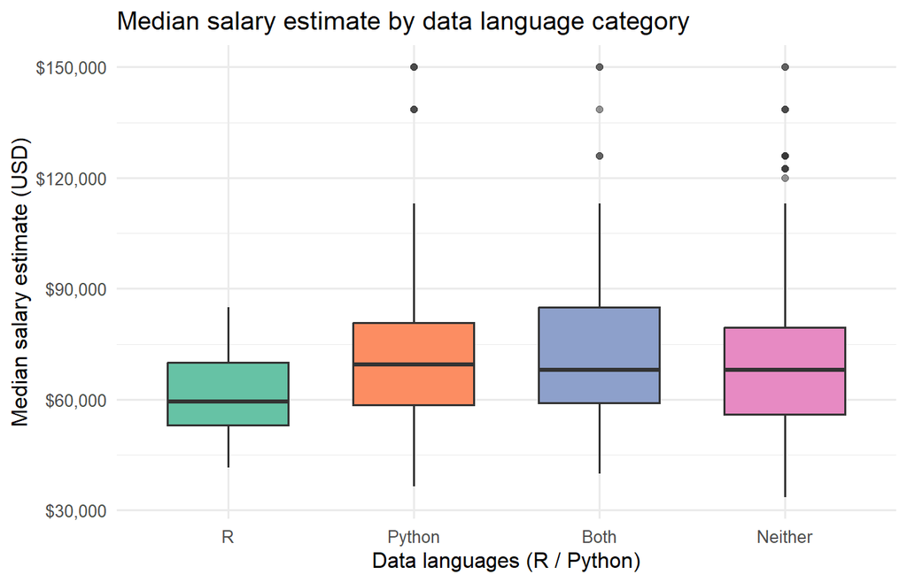

Postings per language category (with salary recorded)

| Data languages | Postings (n) |
| --- | --- |
| R | 11 |
| Python | 63 |
| Both | 65 |
| Neither | 261 |

**Interpretation:** Boxes show the **median and spread** of salary estimates within each language group. Overlapping boxes suggest little separation by R/Python mention in this sample; large differences may reflect few postings per group (see table above) rather than a market-wide effect. Many postings have missing or non-standard language text, so categories are approximate. **Neither** often means SQL/Excel-only or unstated languages — not “no technical skills.”

## Limitations

- **Small sample** (402 postings): estimates are unstable; subgroup counts for R/Python/Both are especially thin.
- **Extraction error**: experience may appear as text or `NA`; salaries are estimates, not verified offers.
- **Confounding**: location, company size, and job title are not modeled here.
- **Language coding**: derived from free-text fields; misclassification of edge cases (e.g., “R” inside other tokens) is possible.

Further work would use a larger, representative sample and multivariate models (location, industry, seniority) before drawing hiring or compensation conclusions.